# 7_tibble

ley

2019年10月20日

# 使用tibble实现简单数据框

这一部分作者也写的很简洁，无外乎建议我们使用tibble数据框来替代data.frame数据框，还有就是简单的创建和使用tibble数据框

由于jupyter对tibble数据框不支持，这里尽管会写，但是看不出来一些差异，所以还会在RDataScience_test目录里用Rmd写一份

```r
# 加载tidyverse包
library(tidyverse)
```

## 创建tibble

```r
### 从data.frame创建tibble
iris  # 看data.frame
```

```
##     Sepal.Length Sepal.Width Petal.Length Petal.Width    Species
## 1            5.1         3.5          1.4         0.2     setosa
## 2            4.9         3.0          1.4         0.2     setosa
## 3            4.7         3.2          1.3         0.2     setosa
## 4            4.6         3.1          1.5         0.2     setosa
## 5            5.0         3.6          1.4         0.2     setosa
## 6            5.4         3.9          1.7         0.4     setosa
## 7            4.6         3.4          1.4         0.3     setosa
## 8            5.0         3.4          1.5         0.2     setosa
## 9            4.4         2.9          1.4         0.2     setosa
## 10           4.9         3.1          1.5         0.1     setosa
## 11           5.4         3.7          1.5         0.2     setosa
## 12           4.8         3.4          1.6         0.2     setosa
## 13           4.8         3.0          1.4         0.1     setosa
## 14           4.3         3.0          1.1         0.1     setosa
```

[output cut: 136 more lines]

```r
as_tibble(iris)
```

```
## # A tibble: 150 x 5
##    Sepal.Length Sepal.Width Petal.Length Petal.Width Species
##           <dbl>       <dbl>        <dbl>       <dbl> <fct>
##  1          5.1         3.5          1.4         0.2 setosa
##  2          4.9         3            1.4         0.2 setosa
##  3          4.7         3.2          1.3         0.2 setosa
##  4          4.6         3.1          1.5         0.2 setosa
##  5          5           3.6          1.4         0.2 setosa
##  6          5.4         3.9          1.7         0.4 setosa
##  7          4.6         3.4          1.4         0.3 setosa
##  8          5           3.4          1.5         0.2 setosa
##  9          4.4         2.9          1.4         0.2 setosa
## 10          4.9         3.1          1.5         0.1 setosa
## # ... with 140 more rows
```

```r
##  通过tibble()函数使用vector创建tibble
tibble(
    x = 1:10,
    y = 1,
    z= x^2 + y)
```

```
## # A tibble: 10 x 3
##        x     y     z
##    <int> <dbl> <dbl>
##  1     1     1     2
##  2     2     1     5
##  3     3     1    10
##  4     4     1    17
##  5     5     1    26
##  6     6     1    37
##  7     7     1    50
##  8     8     1    65
##  9     9     1    82
## 10    10     1   101
```

tibble尽管是新的，但相比data.frame功能要少，不过接受R中无效的变量名称，用反引号引起来即可,使用这些变量的时候也要使用反引号

```r
tb <- tibble(
    `)` = "smile",
    ` ` = "space",
    `2000` = "number")
tb
```

```
## # A tibble: 1 x 3
##   `)`   ` `   `2000`
##   <chr> <chr> <chr>
## 1 smile space number
```

```r
# 也可以使用tribble()函数创建tibble，列标题由公式(~开头)定义，数据条目以逗号分隔
tribble(
    ~x,~y,~z,
    #--|--|--# 是注释
    "a", 2, 3.6,
    "b", 1, 8.4
)
```

```
## # A tibble: 2 x 3
##   x         y     z
##   <chr> <dbl> <dbl>
## 1 a         2   3.6
## 2 b         1   8.4
```

## 对比 tibble与data.frame

### 打印的差异

tibble默认只显示前10行，而且列是适合屏幕的，还打印数据类型，jupyter不支持，看不出来；data.frame的打印就省略了

```r
tibble(
    a = lubridate::now() + runif(1e3)*86400,
    b = lubridate::today() + runif(1e3)*30,
    c = 1:1e3,
    d = runif(1e3),
    e = sample(letters, 1e3, replace = T)
)
```

```
## # A tibble: 1,000 x 5
##    a                   b              c      d e
##    <dttm>              <date>     <int>  <dbl> <chr>
##  1 2019-10-21 06:36:37 2019-11-07     1 0.142  c
##  2 2019-10-21 13:08:53 2019-10-30     2 0.793  u
##  3 2019-10-20 21:58:41 2019-11-15     3 0.976  y
##  4 2019-10-21 01:34:17 2019-11-01     4 0.919  v
##  5 2019-10-20 23:03:25 2019-11-01     5 0.808  d
##  6 2019-10-21 02:32:57 2019-11-12     6 0.0603 c
##  7 2019-10-21 09:41:35 2019-11-16     7 0.147  t
##  8 2019-10-21 05:28:59 2019-11-13     8 0.919  u
##  9 2019-10-21 05:05:59 2019-11-08     9 0.0271 v
## 10 2019-10-21 18:47:05 2019-11-01    10 0.758  v
## # ... with 990 more rows
```

```r
# 更改默认显示输出
# 使用print()函数，n：行数，width：显示宽度
nycflights13::flights %>%
print(n = 10, width = Inf)
```

```
## # A tibble: 336,776 x 19
##     year month   day dep_time sched_dep_time dep_delay arr_time
##    <int> <int> <int>    <int>          <int>     <dbl>    <int>
##  1  2013     1     1      517            515         2      830
##  2  2013     1     1      533            529         4      850
##  3  2013     1     1      542            540         2      923
##  4  2013     1     1      544            545        -1     1004
##  5  2013     1     1      554            600        -6      812
##  6  2013     1     1      554            558        -4      740
##  7  2013     1     1      555            600        -5      913
##  8  2013     1     1      557            600        -3      709
##  9  2013     1     1      557            600        -3      838
## 10  2013     1     1      558            600        -2      753
##    sched_arr_time arr_delay carrier flight tailnum origin dest  air_time
##             <int>     <dbl> <chr>    <int> <chr>   <chr>  <chr>    <dbl>
```

[output cut: 23 more lines]

还可以通过设置以下选项来控制默认的打印方式。

• options(tibble.print_max = n, tibble.pring_min = m)：如果多于m行，则只打印出n行。options(tibble.print_min = Inf)表示总是打印所有行。

• options(tibble.width = Inf)表示总是打印所有列，不考虑屏幕的宽度。

### 取子集

取子集的方法无非是用“$”和[[]]

```r
df <- tibble(
    x = runif(5),
    y = rnorm(5)
)

df$x
```

```
## [1] 0.5355334 0.5387764 0.6931180 0.7635123 0.6544144
```

```r
df[["x"]]
```

```
## [1] 0.5355334 0.5387764 0.6931180 0.7635123 0.6544144
```

```r
df[,"x"]
```

```
## # A tibble: 5 x 1
##       x
##   <dbl>
## 1 0.536
## 2 0.539
## 3 0.693
## 4 0.764
## 5 0.654
```

```r
df[,1]
```

```
## # A tibble: 5 x 1
##       x
##   <dbl>
## 1 0.536
## 2 0.539
## 3 0.693
## 4 0.764
## 5 0.654
```

```r
# 要想在管道中使用这些提取操作，使用特殊占位符"."
df %>% .$x
```

```
## [1] 0.5355334 0.5387764 0.6931180 0.7635123 0.6544144
```

```r
df %>% .[["x"]]
```

```
## [1] 0.5355334 0.5387764 0.6931180 0.7635123 0.6544144
```

与data.frame相比，tibble更严格：它不能进行部分匹配，如果想要访问的列不存在，它会生成一条警告信息。

### 与旧代码进行交互

有些函数不支持tibble，可以使用as.data.frame()函数转换

# (1) 如何识别一个对象是否为tibble？

# 直接打印出来即可，显示上很容易区别

```r
# (2) 对比在data.frame和等价的tibble上进行的以下操作。有何区别？
# 为什么默认的数据框操作会让人感到沮丧

# df <-data.frame(abc =1, xyz ="a")
# df$x
# df[, "xyz"]
# df[, c("abc", "xyz")]
```

```r
df <-data.frame(abc =1, xyz ="a")
df$x
```

```
## [1] a
## Levels: a
```

```r
df[, "xyz"]
```

```
## [1] a
## Levels: a
```

```r
df[, c("abc", "xyz")]
```

```
##   abc xyz
## 1   1   a
```

```r
df <-tibble(abc =1, xyz ="a")
df$x # tibble更加严格，不能模糊匹配
```

[output not shown]

```r
df[, "xyz"]
```

```
## # A tibble: 1 x 1
##   xyz
##   <chr>
## 1 a
```

```r
df[, c("abc", "xyz")]
```

```
## # A tibble: 1 x 2
##     abc xyz
##   <dbl> <chr>
## 1     1 a
```

```r
## (3) 如果将一个变量的名称保存在一个对象中，
# 如var  <-  "mpg"，如何从tibble中提取出这个变量？

# 用上面的例子
var <- "xyz"
# df%var # 这样不可以
df[,var]
```

```
## # A tibble: 1 x 1
##   xyz
##   <chr>
## 1 a
```

```r
df[[var]]
```

```
## [1] "a"
```

```r
# df$`var` # 这样也不可以
```

```r
## (4) 在以下的数据框中练习如何引用不符合语法规则的变量名。
## a. 提取名称为1的变量。
## b. 绘制表示变量1和变量2关系的散点图。
## c. 创建一个名称为3的新列，其值为列2除以列1。
## d. 将这些列重新命名为one、two和three。
annoying <-tibble(
    `1` =1:10,
    `2` = `1` *2+rnorm(length(`1`))
)
```

```r
# a
annoying$`1`
```

```
##  [1]  1  2  3  4  5  6  7  8  9 10
```

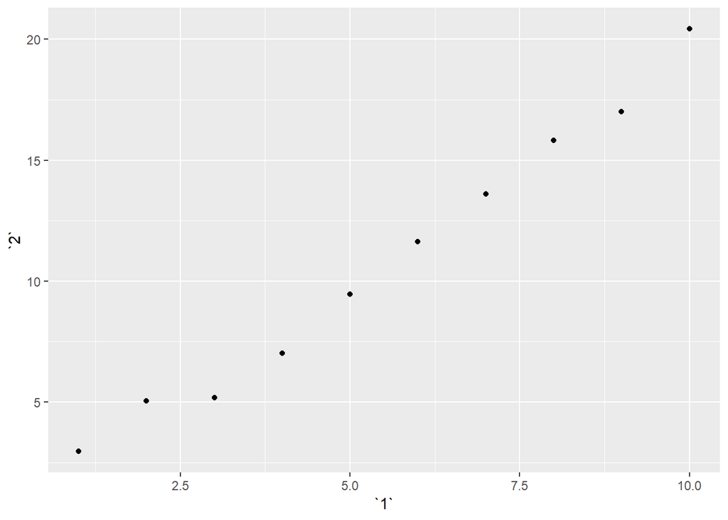

```r
# b
ggplot(annoying) + geom_point(aes(x = `1`, y = `2`))
```

```r
# c
(annoying <- mutate(annoying, `3` = `2`/`1`))
```

```
## # A tibble: 10 x 3
##      `1`   `2`   `3`
##    <int> <dbl> <dbl>
##  1     1  2.95  2.95
##  2     2  5.05  2.52
##  3     3  5.17  1.72
##  4     4  7.02  1.76
##  5     5  9.45  1.89
##  6     6 11.6   1.94
##  7     7 13.6   1.94
##  8     8 15.8   1.98
##  9     9 17.0   1.89
## 10    10 20.4   2.04
```

```r
# d
colnames(annoying) = c("one","two","three")
annoying
```

```
## # A tibble: 10 x 3
##      one   two three
##    <int> <dbl> <dbl>
##  1     1  2.95  2.95
##  2     2  5.05  2.52
##  3     3  5.17  1.72
##  4     4  7.02  1.76
##  5     5  9.45  1.89
##  6     6 11.6   1.94
##  7     7 13.6   1.94
##  8     8 15.8   1.98
##  9     9 17.0   1.89
## 10    10 20.4   2.04
```

结束